# Ford GoBike Data Explanation

## by Emefiele-konyeri Awinrin

## Investigation Overview

In this investigation, i want to find out how a period of time(hour,day,month) could affect the duration of trips and demand for bikes, what distance different users cover from the start station to the end station, what geographical area is this bike system more popular and how well users use the 'Bikeshare For All' program

## Dataset Overview

The Ford Gobike system data consists of 631,793 observations and 14 features('duration_sec', 'start_time', 'end_time', 'start_station_id', 'start_station_name', 'start_station_latitude', 'start_station_longitude', 'end_station_id', 'end_station_name', 'end_station_latitude', 'end_station_longitude', 'bike_id', 'user_type', 'bike_share_for_all_trip'), after data cleaning the dataset was transformed to 482,555 observations and 23 features(additional features: 'start_neighbourhood', 'start_city', 'end_neighbourhood', 'end_city', 'distances(km)', 'start_date', 'start_hour', 'start_day', 'duration_min').

## Distribution Of Duration(minutes)

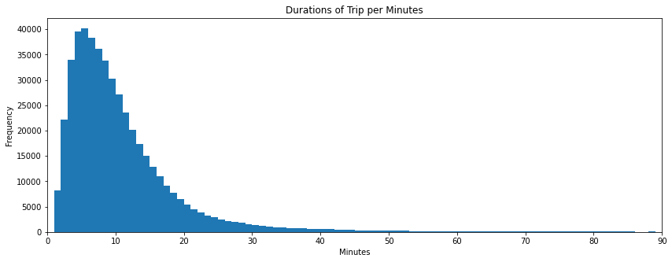

## Distribution of Hour of the day with high demand for bikes

The distribution of this bar graph is bimodal which means in each day there will be two periods in time with very high demands for bikes. The two hours of the day with highest demands are 5PM and 8AM respectively.

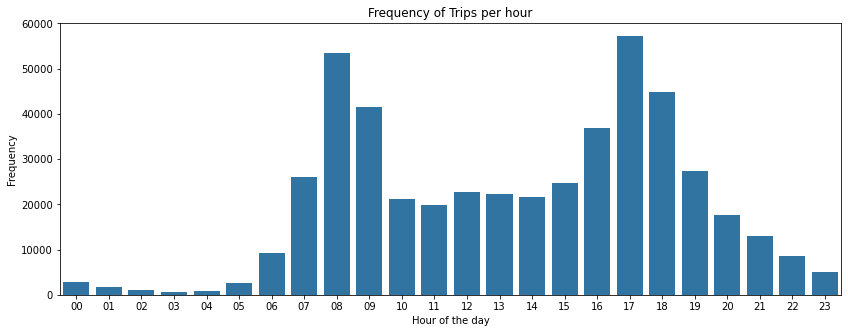

## Distribution day of the week with the high demands for bikes

The distribution shows a rise in demand from the start of the week until weekends, which means alot of the users are commuters going to work other than for recreation

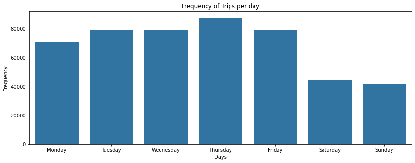

## The average duration of trips of different users at each day of the week

Customers tend to have a higher duration of trips than Subscribers for every day of the week. Saturdays and Sundays seems to be the days with the highest average durations which not coincidentally is a weekend. Users spend more time on trips during the weekend maybe for recreation or for visitation and some sort.

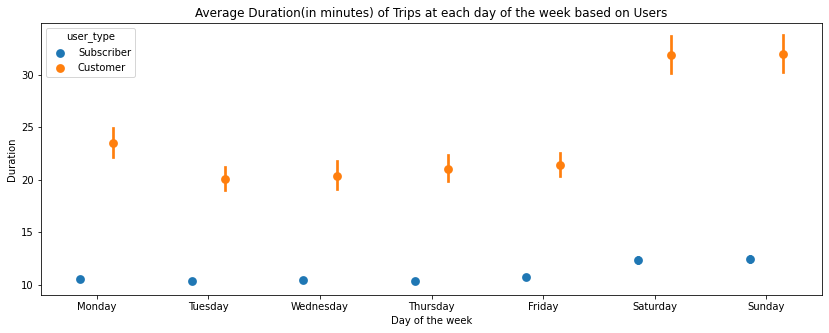

## The time of the day different users demand bikes

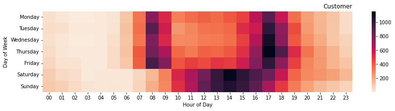

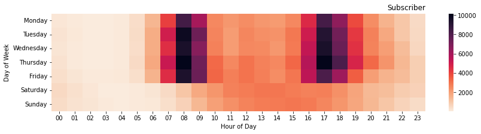

## Duration of trip for each day in the first quarter of the year

Even though there are variations in the trends we can still see an increase in peak of duration from january to march.

[figure not shown]

## Distribution of distance covered by each rider from the start station to the end station

The distribution is positively skewed to the right with the interpretation that the frequency of the distance from the start and end station(s) decreases with an increase in distance after a range between 0 to 1 kilometre. Which means most users tends to end their trip at a station not more than 2 kilometres from the start station.

```
(0.0, 10.0)
```

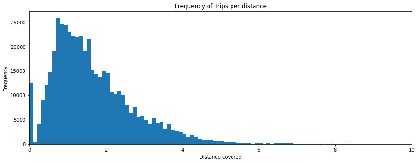

## The average distance covered by each type of user from start station to end station

Customers have an average distance a little more than subscribers which doesn't really distinguish much about them

```
(-0.5, 10.0)
```

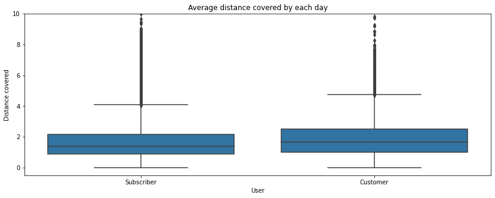

## Top 20 neighbourhoods with the most demand for bikes

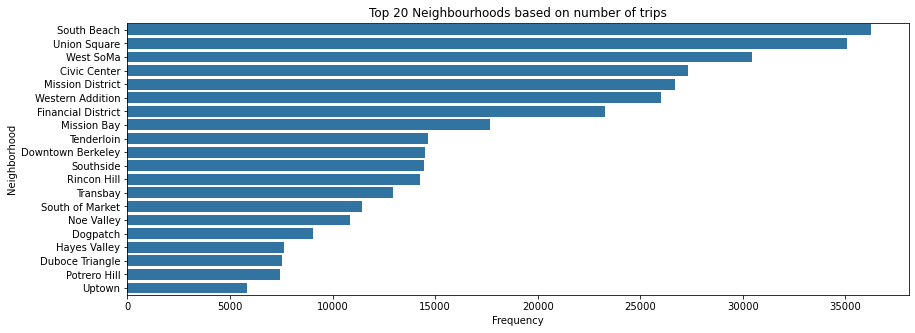

## The proportion of bikeshare usage between each cities

San Francisco seems to be the major city were the Ford Gobike system is being used with 72% of the total number of trips in the nation.

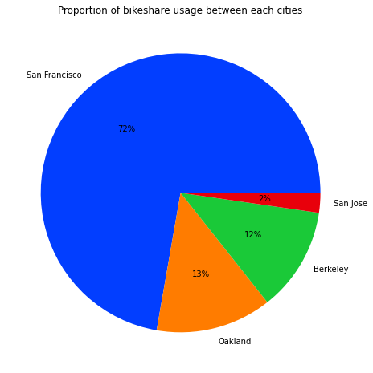

## The relationship between type of user and bikeshare for all trip membership plan

Most subscribers don't use bike share for all trip plan, customers don't use bikeshare for all trip plan. 'BikeShare For All' program is the nation’s most comprehensive bike share equity program, includes equitable station siting, outreach, and discounted pricing to help expand transportation access to underserved communities.

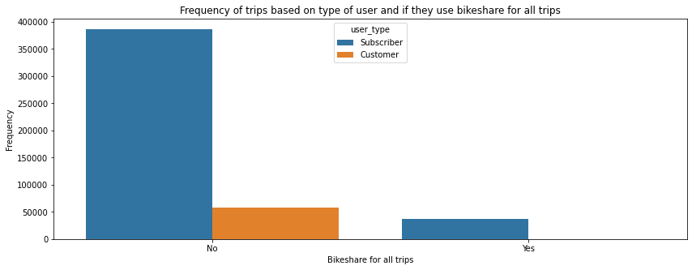